## Differential Accessibility Analysis of ATAC-seq data

## Introduction

The ATAC-seq data used in this workflow was generated as part of a study that investigated the regulatory role of short-chain fatty acids (SCFAs) propionate and butyrate in the context of colorectal cancer (CRC). Briefly, epigenomic and transcriptomic profiles were compared in SCFA-treated and untreated CRC cells, normal cells and in mouse intestines, with the goal of gaining insight into changes in accessibility and expression of CRC-relevant genes.

The data set used in this workflow comes from propionyl ATAC-seq in CRC cells. The untreataed condition is used as a control. The data identifies genomic regions showing increased transposase accessibility following treatment (10mM) with sodium propionate (NaPr).

Once `diffbind.sh` has been run and the resulting `.RData` object and `report.csv` file are ready to be loaded into `R`, `BiocManager`, `DiffBind`, `EnsDb.Hsapiens.v86`, `AnnotationDbi2`, `org.Hs.eg.db`, `ChIPpeakAnno`, `GenomicRanges`, packages will first have to be installed.

Once the `.RData` object has been loaded and the dependencies installed, `DiffBind` will be used for exploratory analysis and for identifying differentially bound genomic coordinates. `GenomicRanges` will then be used to convert genomic coordinates to an annotated object. `ChIPpeakAnno` will be used for annotation of differentially bound regions, and `ChIPseeker` will provide average profile and heatmap of peak accessibility to TSS regions and genomic feature distribution. Finally, `ReactomePA` will be used to perform pathway analysis.

## Setup

This R Markdown (.Rmd) file will provide a walk-through of exploratory data analysis followed by differential accessibility analysis, annotation and pathway analysis of propionyl ATAC-seq data. Each `Rmd` file has an initial `setup` chunk that applies some settings to all of the code chunks.

As in a regular R script in RStudio, a single line of code can be run with Command-Enter (Mac OS) or Ctrl-Enter (Windows). Whole chunks of code can be run with Command(/Ctrl) + Shift + Enter **or** by clicking the green “>” button in the top-right corner of the chunk. Alternatively, these options can also be implemented by selecting lines of code and choosing the desired option from the drop-down menu in the “Run” tab, in the top-right corner of the of Source section of RStudio.

To comment or uncomment a series of lines, highlight the lines and use Command(/Ctrl) + Shift + C.

The following `Bioconductor` `R` packages are required for this workflow. They can be installed using the following commands:

```r
if (!requireNamespace("BiocManager", quietly = TRUE))
    install.packages("BiocManager")
BiocManager::install("EnsDb.Hsapiens.v86")
install.packages("AnnotationDbi")
install.packages("org.Hs.eg.db")
install.packages("ChIPpeakAnno")
install.packages("GenomicRanges")

# If install.packages("packagename") command fails in newer versions of R uncomment and run the commands:
# if (!require("BiocManager", quietly = TRUE))
#    install.packages("BiocManager")
# BiocManager::install("packagename")
```

Once installed, load the required packages.

```r
library(EnsDb.Hsapiens.v86)
library(AnnotationDbi)
library(org.Hs.eg.db)
library(GenomicRanges)
library(DiffBind)
library(ChIPpeakAnno)
```

## Exploratory and Differential Accessibility Analysis

Before annotation and pathway analysis it good to first visualize the data and perform quality control checks. This can be done by loading the `.RData` object generated by `Diffbind` using `diffbind_chip.R` script provided in the repository.

```r
load("~/Desktop/Data/ATAC-seq/prop_atac.RData")
```

The `atac.RData` file should contain the `diff` object, which includes differential accessibility and contrast/covariate information. Make sure they are loaded into your global environment.

Check data frame information:

```r
# This will display experimental variables defined in the sampleSheet and differentially bound sites identified by DESeq2.
diff
```

```
## 6 Samples, 124131 sites in matrix:
##      ID     Factor Condition Treatment Replicate Caller Intervals FRiP
## 1  cnt1    control       24h      0 mM         1 counts    124131 0.38
## 2  cnt2    control       24h      0 mM         2 counts    124131 0.29
## 3  cnt3    control       24h      0 mM         3 counts    124131 0.38
## 4 prop1 propionate       24h     10 mM         1 counts    124131 0.36
## 5 prop2 propionate       24h     10 mM         2 counts    124131 0.35
## 6 prop3 propionate       24h     10 mM         3 counts    124131 0.40
##
## 1 Contrast:
##    Group1 Members1     Group2 Members2 DB.DESeq2
## 1 control        3 propionate        3     22238
```

Next, it’s good to visualize the correlation between different replicates within each condition.

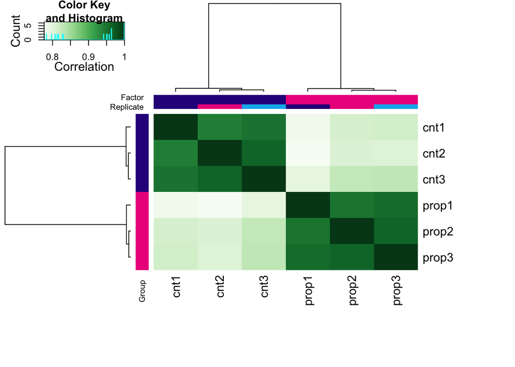

```r
# "dba" is function that is built into DiffBind package and can be used to make plots from the "diff" object.
# "Contrast" refers to the differential analysis by factor (or condition).
# In this example, the contrast is between propionate treated vs untreated groups defined in the sampleSheet.
# Replicates from the same condition should have a higher correlation score than those from different conditions.

dba.plotHeatmap(diff, contrast=1)
```

```r
# Alternatively, you could also run:
#plot(diff, contrast=1)
```

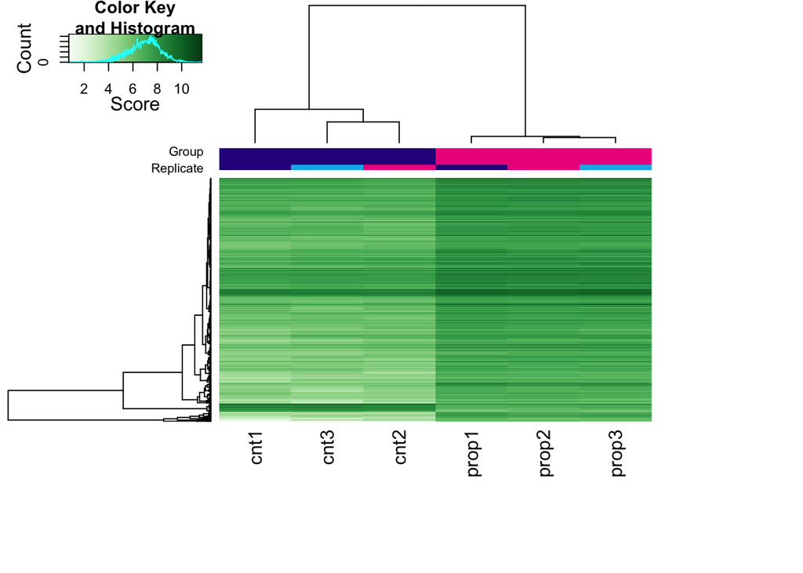

```r
# Generate a accessibility affinity heatmap showing affinities for differentially bound sites.
dba.plotHeatmap(diff, contrast=1, correlations=FALSE)
```

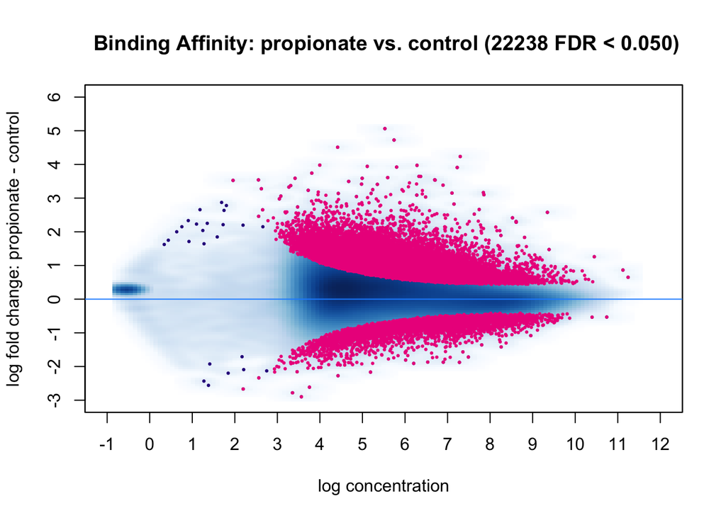

```r
# Make an MA plot showing differentially bound sites associated with the two histone marks.
dba.plotMA(diff, bFlip=TRUE)
```

```r
# Sites preferentially associated with Kpr above a significance threshold are shown as red dots in the upper panel.
```

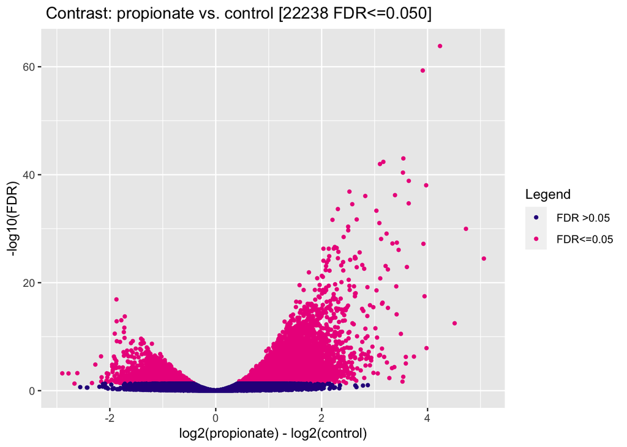

```r
# Make a volcano plot showing the log2 fold change vs -log10 FDR-adjusted (<0.05) p-value.
dba.plotVolcano(diff, bFlip=TRUE)
```

## Annotation of Differentially Bound Regions

```r
# Create an annotation data object.
annoData <- annoGR(EnsDb.Hsapiens.v86, feature="gene")
info(annoData)
```

```
## annoGR object;
## # source:  EnsDb.Hsapiens.v86
## # create at:  Sun Mar 03 00:00:00 2024 UTC
## # feature:  gene
## # Db type: EnsDb
## # Type of Gene ID: Ensembl Gene ID
## # Supporting package: ensembldb
## # Db created by: ensembldb package from Bioconductor
## # script_version: 0.3.0
## # Creation time: Thu May 18 16:32:27 2017
## # ensembl_version: 86
## # ensembl_host: localhost
## # Organism: homo_sapiens
## # taxonomy_id: 9606
## # genome_build: GRCh38
## # DBSCHEMAVERSION: 2.0
```

```r
annoData[1:2]
```

```
## annoGR object with 2 ranges and 1 metadata column:
##                   seqnames      ranges strand |   gene_name
##                      <Rle>   <IRanges>  <Rle> | <character>
##   ENSG00000223972     chr1 11869-14409      + |     DDX11L1
##   ENSG00000227232     chr1 14404-29570      - |      WASH7P
##   -------
##   seqinfo: 357 sequences from GRCh38 genome
```

First, load the `report.csv` file generated by `DiffBind` and create a new object, in this case *prop*. Make sure the data frame loaded correctly and inspect the top rows by using `head(object)`.

```r
prop <- read.csv("prop_atac_report.csv", header=TRUE)
head(prop)
```

```
##   X seqnames    start      end width strand Conc Conc_0mM Conc_10mM  Fold
## 1 1    chr12  6719795  6720295   501      * 7.30     3.99      8.22 -4.23
## 2 2    chr14 23646746 23647246   501      * 7.23     4.22      8.13 -3.91
## 3 3    chr19  2392765  2393265   501      * 6.70     4.04      7.58 -3.54
## 4 4     chrX 23786476 23786976   501      * 7.84     5.52      8.69 -3.16
## 5 5    chr10 90912914 90913414   501      * 7.85     5.59      8.70 -3.10
## 6 6    chr10 90913746 90914246   501      * 6.71     4.05      7.59 -3.54
##    p.value      FDR
## 1 1.18e-69 1.46e-64
## 2 8.14e-65 5.05e-60
## 3 2.32e-48 9.60e-44
## 4 1.35e-47 4.18e-43
## 5 4.19e-47 1.04e-42
## 6 1.98e-45 4.10e-41
```

Next, make a `GRanges` data frame from report table:

```r
propgr <- makeGRangesFromDataFrame(prop, keep.extra.columns=TRUE)
propgr
```

```
## GRanges object with 22238 ranges and 7 metadata columns:
##           seqnames            ranges strand |         X      Conc  Conc_0mM
##              <Rle>         <IRanges>  <Rle> | <integer> <numeric> <numeric>
##       [1]    chr12   6719795-6720295      * |         1       7.3      3.99
##       [2]    chr14 23646746-23647246      * |         2      7.23      4.22
##       [3]    chr19   2392765-2393265      * |         3       6.7      4.04
##       [4]     chrX 23786476-23786976      * |         4      7.84      5.52
##       [5]    chr10 90912914-90913414      * |         5      7.85      5.59
##       ...      ...               ...    ... .       ...       ...       ...
##   [22234]     chr2 95323291-95323791      * |     22234      7.27      7.01
##   [22235]    chr17 44333977-44334477      * |     22235      5.02      4.57
##   [22236]    chr17   8060140-8060640      * |     22236      5.01      4.54
##   [22237]    chr17 17841707-17842207      * |     22237      7.23      6.96
##   [22238]    chr22 17952317-17952817      * |     22238      5.58      5.22
##           Conc_10mM      Fold   p.value       FDR
##           <numeric> <numeric> <numeric> <numeric>
##       [1]      8.22     -4.23  1.18e-69  1.46e-64
##       [2]      8.13     -3.91  8.14e-65  5.05e-60
##       [3]      7.58     -3.54  2.32e-48   9.6e-44
##       [4]      8.69     -3.16  1.35e-47  4.18e-43
##       [5]       8.7      -3.1  4.19e-47  1.04e-42
##       ...       ...       ...       ...       ...
##   [22234]      7.49     -0.48   0.00895      0.05
##   [22235]      5.37      -0.8   0.00896      0.05
##   [22236]      5.37     -0.84   0.00896      0.05
##   [22237]      7.45     -0.49   0.00896      0.05
##   [22238]      5.87     -0.65   0.00896      0.05
##   -------
##   seqinfo: 23 sequences from an unspecified genome; no seqlengths
```

Annotate to within +/- 1000 bp of transcription start sites (TSS) of a transcript.

```r
prop.anno <- annotatePeakInBatch(propgr, AnnotationData=annoData, output="both", maxgap=1000L, select="all")
```

Annotate by feature.

```r
prop.anno$gene_name <- annoData$gene_name[match(prop.anno$feature, names(annoData))]
head(prop.anno$feature)
```

```
## [1] "ENSG00000270068" "ENSG00000100867" "ENSG00000178297" "ENSG00000130066"
## [5] "ENSG00000148677" "LRG_379"
```

Annotate by gene symbol.

```r
prop.anno$symbol <- mapIds(org.Hs.eg.db,
                     keys=prop.anno$feature,
                     column="SYMBOL",
                     keytype="ENSEMBL",
                     multiVals="first")
prop.anno
```

```
## GRanges object with 32900 ranges and 18 metadata columns:
##                          seqnames            ranges strand |         X
##                             <Rle>         <IRanges>  <Rle> | <integer>
##   X00001.ENSG00000270068    chr12   6719795-6720295      * |         1
##   X00002.ENSG00000100867    chr14 23646746-23647246      * |         2
##   X00003.ENSG00000178297    chr19   2392765-2393265      * |         3
##   X00004.ENSG00000130066     chrX 23786476-23786976      * |         4
##   X00005.ENSG00000148677    chr10 90912914-90913414      * |         5
##                      ...      ...               ...    ... .       ...
##   X22235.ENSG00000267211    chr17 44333977-44334477      * |     22235
##   X22236.ENSG00000263427    chr17   8060140-8060640      * |     22236
##   X22237.ENSG00000072310    chr17 17841707-17842207      * |     22237
##   X22238.ENSG00000243156    chr22 17952317-17952817      * |     22238
##   X22238.ENSG00000207780    chr22 17952317-17952817      * |     22238
##                               Conc  Conc_0mM Conc_10mM      Fold   p.value
##                          <numeric> <numeric> <numeric> <numeric> <numeric>
##   X00001.ENSG00000270068       7.3      3.99      8.22     -4.23  1.18e-69
##   X00002.ENSG00000100867      7.23      4.22      8.13     -3.91  8.14e-65
##   X00003.ENSG00000178297       6.7      4.04      7.58     -3.54  2.32e-48
##   X00004.ENSG00000130066      7.84      5.52      8.69     -3.16  1.35e-47
##   X00005.ENSG00000148677      7.85      5.59       8.7      -3.1  4.19e-47
##                      ...       ...       ...       ...       ...       ...
##   X22235.ENSG00000267211      5.02      4.57      5.37      -0.8   0.00896
##   X22236.ENSG00000263427      5.01      4.54      5.37     -0.84   0.00896
##   X22237.ENSG00000072310      7.23      6.96      7.45     -0.49   0.00896
##   X22238.ENSG00000243156      5.58      5.22      5.87     -0.65   0.00896
##   X22238.ENSG00000207780      5.58      5.22      5.87     -0.65   0.00896
##                                FDR        peak         feature start_position
##                          <numeric> <character>     <character>      <integer>
##   X00001.ENSG00000270068  1.46e-64       00001 ENSG00000270068        6723233
##   X00002.ENSG00000100867  5.05e-60       00002 ENSG00000100867       23630115
##   X00003.ENSG00000178297   9.6e-44       00003 ENSG00000178297        2389771
##   X00004.ENSG00000130066  4.18e-43       00004 ENSG00000130066       23783173
##   X00005.ENSG00000148677  1.04e-42       00005 ENSG00000148677       90912096
##                      ...       ...         ...             ...            ...
##   X22235.ENSG00000267211      0.05       22235 ENSG00000267211       44328613
##   X22236.ENSG00000263427      0.05       22236 ENSG00000263427        8056225
##   X22237.ENSG00000072310      0.05       22237 ENSG00000072310       17810399
##   X22238.ENSG00000243156      0.05       22238 ENSG00000243156       17787649
##   X22238.ENSG00000207780      0.05       22238 ENSG00000207780       17980868
```

[output cut: 26 more lines]

```
##                          fromOverlappingOrNearest     gene_name      symbol
##                                       <character>   <character> <character>
##   X00001.ENSG00000270068          NearestLocation  RP4-761J14.9        <NA>
##   X00002.ENSG00000100867          NearestLocation         DHRS2       DHRS2
##   X00003.ENSG00000178297          NearestLocation       TMPRSS9     TMPRSS9
##   X00004.ENSG00000130066          NearestLocation          SAT1        SAT1
##   X00005.ENSG00000148677              Overlapping        ANKRD1      ANKRD1
##                      ...                      ...           ...         ...
##   X22235.ENSG00000267211          NearestLocation  RP5-1067M6.3        <NA>
##   X22236.ENSG00000263427          NearestLocation RP11-599B13.3        <NA>
##   X22237.ENSG00000072310          NearestLocation        SREBF1      SREBF1
##   X22238.ENSG00000243156              Overlapping        MICAL3      MICAL3
##   X22238.ENSG00000207780          NearestLocation        MIR648      MIR648
##   -------
##   seqinfo: 23 sequences from an unspecified genome; no seqlengths
```

Annotate by gene entrezID.

```r
prop.anno$entrezID <- mapIds(org.Hs.eg.db,
                     keys=prop.anno$feature,
                     column="ENTREZID",
                     keytype="ENSEMBL",
                     multiVals="first")
prop.anno
```

```
## GRanges object with 32900 ranges and 19 metadata columns:
##                          seqnames            ranges strand |         X
##                             <Rle>         <IRanges>  <Rle> | <integer>
##   X00001.ENSG00000270068    chr12   6719795-6720295      * |         1
##   X00002.ENSG00000100867    chr14 23646746-23647246      * |         2
##   X00003.ENSG00000178297    chr19   2392765-2393265      * |         3
##   X00004.ENSG00000130066     chrX 23786476-23786976      * |         4
##   X00005.ENSG00000148677    chr10 90912914-90913414      * |         5
##                      ...      ...               ...    ... .       ...
##   X22235.ENSG00000267211    chr17 44333977-44334477      * |     22235
##   X22236.ENSG00000263427    chr17   8060140-8060640      * |     22236
##   X22237.ENSG00000072310    chr17 17841707-17842207      * |     22237
##   X22238.ENSG00000243156    chr22 17952317-17952817      * |     22238
##   X22238.ENSG00000207780    chr22 17952317-17952817      * |     22238
##                               Conc  Conc_0mM Conc_10mM      Fold   p.value
##                          <numeric> <numeric> <numeric> <numeric> <numeric>
##   X00001.ENSG00000270068       7.3      3.99      8.22     -4.23  1.18e-69
##   X00002.ENSG00000100867      7.23      4.22      8.13     -3.91  8.14e-65
##   X00003.ENSG00000178297       6.7      4.04      7.58     -3.54  2.32e-48
##   X00004.ENSG00000130066      7.84      5.52      8.69     -3.16  1.35e-47
##   X00005.ENSG00000148677      7.85      5.59       8.7      -3.1  4.19e-47
##                      ...       ...       ...       ...       ...       ...
##   X22235.ENSG00000267211      5.02      4.57      5.37      -0.8   0.00896
##   X22236.ENSG00000263427      5.01      4.54      5.37     -0.84   0.00896
##   X22237.ENSG00000072310      7.23      6.96      7.45     -0.49   0.00896
##   X22238.ENSG00000243156      5.58      5.22      5.87     -0.65   0.00896
##   X22238.ENSG00000207780      5.58      5.22      5.87     -0.65   0.00896
##                                FDR        peak         feature start_position
##                          <numeric> <character>     <character>      <integer>
##   X00001.ENSG00000270068  1.46e-64       00001 ENSG00000270068        6723233
##   X00002.ENSG00000100867  5.05e-60       00002 ENSG00000100867       23630115
##   X00003.ENSG00000178297   9.6e-44       00003 ENSG00000178297        2389771
##   X00004.ENSG00000130066  4.18e-43       00004 ENSG00000130066       23783173
##   X00005.ENSG00000148677  1.04e-42       00005 ENSG00000148677       90912096
##                      ...       ...         ...             ...            ...
##   X22235.ENSG00000267211      0.05       22235 ENSG00000267211       44328613
##   X22236.ENSG00000263427      0.05       22236 ENSG00000263427        8056225
##   X22237.ENSG00000072310      0.05       22237 ENSG00000072310       17810399
##   X22238.ENSG00000243156      0.05       22238 ENSG00000243156       17787649
##   X22238.ENSG00000207780      0.05       22238 ENSG00000207780       17980868
```

[output cut: 39 more lines]

```
##                             entrezID
##                          <character>
##   X00001.ENSG00000270068        <NA>
##   X00002.ENSG00000100867       10202
##   X00003.ENSG00000178297      360200
##   X00004.ENSG00000130066        6303
##   X00005.ENSG00000148677       27063
##                      ...         ...
##   X22235.ENSG00000267211        <NA>
##   X22236.ENSG00000263427        <NA>
##   X22237.ENSG00000072310        6720
##   X22238.ENSG00000243156       57553
##   X22238.ENSG00000207780      693233
##   -------
##   seqinfo: 23 sequences from an unspecified genome; no seqlengths
```

Next, make a report of the annotated output.

```r
# write annotated output
diffprop <- data.frame(seqnames=seqnames(prop.anno),
  starts=(start(prop.anno)-1),
  ends=end(prop.anno),
  ENSG=prop.anno$feature,
  ENSG.strand=prop.anno$feature_strand,
  insideFeature=prop.anno$insideFeature,
  distancetoFeature=prop.anno$distancetoFeature,
  shortestDistance=prop.anno$shortestDistance,
  symbol=prop.anno$symbol,
  entrezID=prop.anno$entrezID,
  fold=prop.anno$Fold,
  conc=prop.anno$Conc,
  conc_0mM=prop.anno$Conc_0mM,
  conc_10mM=prop.anno$Conc_10mM,
  FDR=prop.anno$FDR)
head(diffprop)
```

```
##   seqnames   starts     ends            ENSG ENSG.strand insideFeature
## 1    chr12  6719794  6720295 ENSG00000270068           +      upstream
## 2    chr14 23646745 23647246 ENSG00000100867           +    downstream
## 3    chr19  2392764  2393265 ENSG00000178297           +        inside
## 4     chrX 23786475 23786976 ENSG00000130066           +    downstream
## 5    chr10 90912913 90913414 ENSG00000148677           -        inside
## 6    chr10 90912913 90913414         LRG_379           -        inside
##   distancetoFeature shortestDistance  symbol entrezID  fold conc conc_0mM
## 1             -3438             2938    <NA>     <NA> -4.23 7.30     3.99
## 2             16631             1107   DHRS2    10202 -3.91 7.23     4.22
## 3              2994             2994 TMPRSS9   360200 -3.54 6.70     4.04
## 4              3303              250    SAT1     6303 -3.16 7.84     5.52
## 5              8362              818  ANKRD1    27063 -3.10 7.85     5.59
## 6              8361              814    <NA>     <NA> -3.10 7.85     5.59
##   conc_10mM      FDR
## 1      8.22 1.46e-64
## 2      8.13 5.05e-60
## 3      7.58 9.60e-44
## 4      8.69 4.18e-43
## 5      8.70 1.04e-42
## 6      8.70 1.04e-42
```

Save the annotated output data table.

```r
write.table(diffprop, file="prop.anno.bed", quote=FALSE, sep="\t", row.names=FALSE, col.names=TRUE)
dim(diffprop)
```

```
## [1] 32900    15
```

**NOTE:** The final output contains a table with features showing positive and negative fold change. In this example, the positive vs negative fold change relationship is reversed, with NaPr treatment associated genes labeled as negative fold change. You may wish to select only those regions showing positive or negative fold change (or increased vs decreased accessibility) by opening the `.report.csv` or `.anno.bed` files in MS Excel, selecting the “fold” column, clicking on “Sort & Filter” and selecting only “Greater Than” or “Less Than” “0” entries.

## Profile of Differential Accessibility to TSS Regions

The next several modules will require `ChIPseeker` and `TxDb.Hsapiens.UCSC.hg38.knownGene` packages.

```r
# Install `ChIPseeker` package:
#if (!requireNamespace("BiocManager", quietly = TRUE))
#    install.packages("BiocManager")
#BiocManager::install("ChIPseeker")
```

```r
# Install `TxDb.Hsapiens.UCSC.hg38.knownGene` package:
#if (!requireNamespace("BiocManager", quietly = TRUE))
#    install.packages("BiocManager")
#BiocManager::install("TxDb.Hsapiens.UCSC.hg38.knownGene")
```

Load the required packages:

```r
library(ChIPseeker)
library(TxDb.Hsapiens.UCSC.hg38.knownGene)
```

Create a *TxDb* object based on the UCSC hg38 assembly of the human genome.

```r
txdb <- TxDb.Hsapiens.UCSC.hg38.knownGene
```

Annotate peaks to 3000 bp upstream and downstream of promoters and generate heatmap.

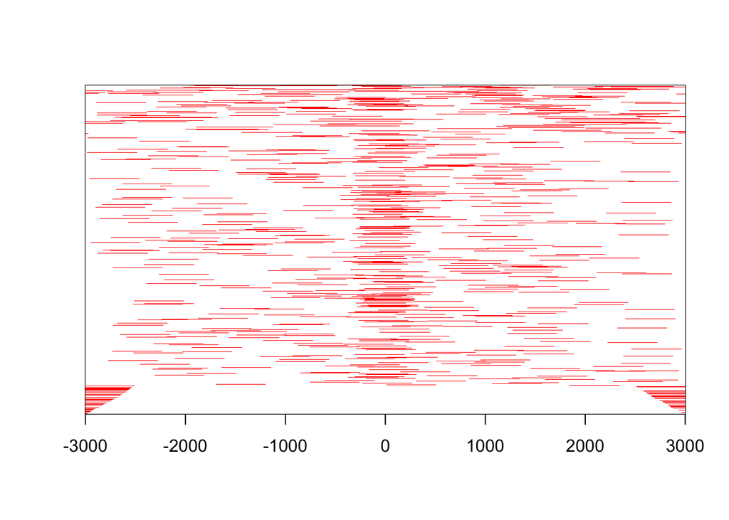

```r
promoter <- getPromoters(TxDb=txdb, upstream=3000, downstream=3000)
tagMatrix <- getTagMatrix(propgr, windows=promoter)
tagHeatmap(tagMatrix, xlim=c(-3000, 3000), color="red")
```

Plot peak distributions profile 3000 bp upstream and downstream of TSS.

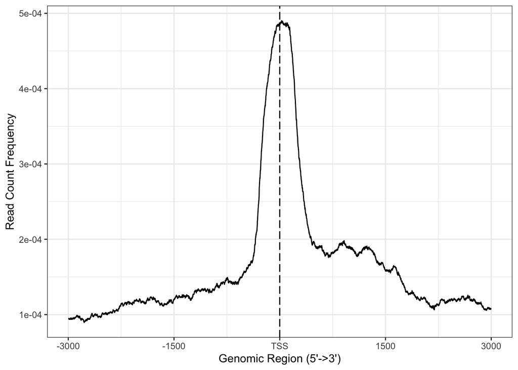

```r
plotAvgProf(tagMatrix, xlim=c(-3000, 3000), xlab="Genomic Region (5'->3')", ylab = "Read Count Frequency")
```

Resample peak distribution profile 1000 times by running bootstrapping with 0.95 confidence cutoff.

```
## >> Running bootstrapping for tag matrix...        2024-03-03 21:54:11
```

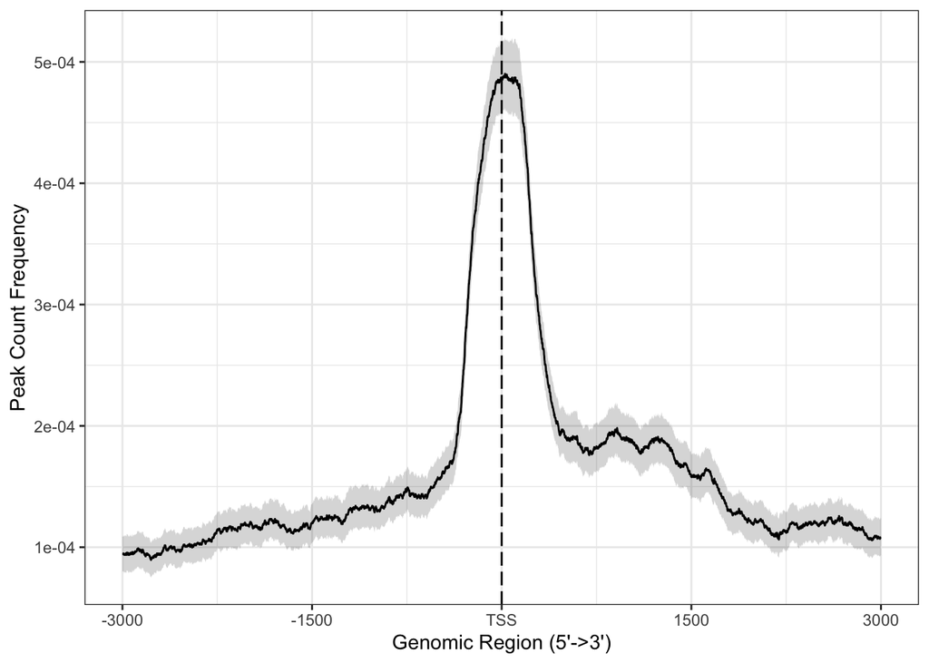

```r
plotAvgProf(tagMatrix, xlim=c(-3000, 3000), conf = 0.95, resample = 1000)
```

Annotate again to 3000 bp upstream and downstream of TSS by using `org.Hs.eg.db`.

```r
peakAnno <- annotatePeak(propgr, tssRegion=c(-3000, 3000), TxDb=txdb, annoDb="org.Hs.eg.db")
```

```
## >> preparing features information...      2024-03-03 21:54:15
## >> identifying nearest features...        2024-03-03 21:54:17
## >> calculating distance from peak to TSS...   2024-03-03 21:54:17
## >> assigning genomic annotation...        2024-03-03 21:54:17
## >> adding gene annotation...          2024-03-03 21:54:55
```

```
## >> assigning chromosome lengths           2024-03-03 21:54:56
## >> done...                    2024-03-03 21:54:56
```

Plot differentially bound feature distribution as a pie or a bar plot.

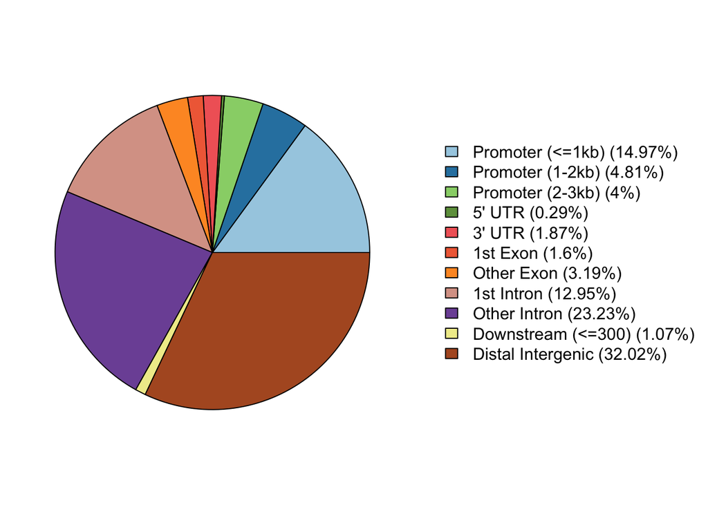

```r
plotAnnoPie(peakAnno)
```

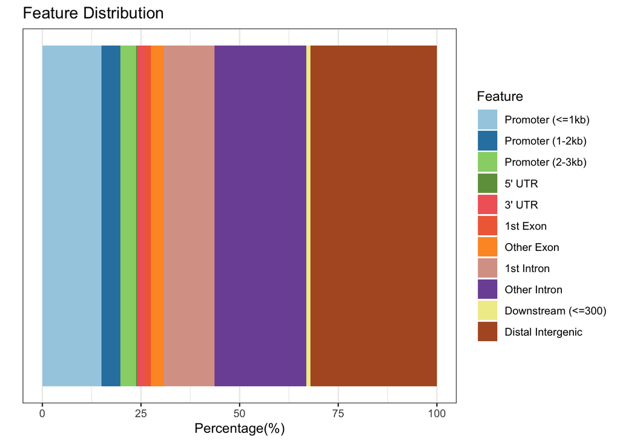

```r
plotAnnoBar(peakAnno)
```

## Pathway Analysis of Differentially Accessible Genes

**NOTE:** As mentioned earlier, in this example, the positive vs negative fold change relationship is reversed, with propionate treatment associated genes assigned negative fold change. Pathways that go up or show enrichment are defined as fold < 0 and vise versa.

```r
# do pathway analysis in Reactome
#if (!requireNamespace("BiocManager", quietly = TRUE))
#    install.packages("BiocManager")
#BiocManager::install("ReactomePA")
library(ReactomePA)
head(diffprop$entrezID)
```

```
## [1] <NA>   10202  360200 6303   27063  <NA>
## 9986 Levels: 100 10000 10002 100033411 100038246 100048912 100049716 ... 9993
```

Check number of features showing increased enrichment or association with NaPr treatment.

```r
diffup <- diffprop[which(diffprop$fold < 0), ]
dim(diffup)
```

```
## [1] 26719    15
```

Check number of features showing decreased enrichment or association with NaPr treatment.

```r
diffdown <- diffprop[which(diffprop$fold > 0), ]
dim(diffdown)
```

```
## [1] 6181   15
```

Identify enriched pathways with p-adjusted value cutoff of 0.05.

```r
de <- (diffprop$entrezID)
length(de)
```

```
## [1] 32900
```

```r
de <- de[!is.na(de)]
head(de)
```

```
## [1] 10202  360200 6303   27063  27063  51108
## 9986 Levels: 100 10000 10002 100033411 100038246 100048912 100049716 ... 9993
```

```r
length(de)
```

```
## [1] 20001
```

```r
x <- enrichPathway(gene=de,pvalueCutoff=0.05, readable=TRUE)
```

Make a dotplot showing pathways that go up or are associated with NaPr treatment.

```r
deup <- diffup$entrezID
deup <- deup[!is.na(deup)]
length(deup)
```

```
## [1] 15508
```

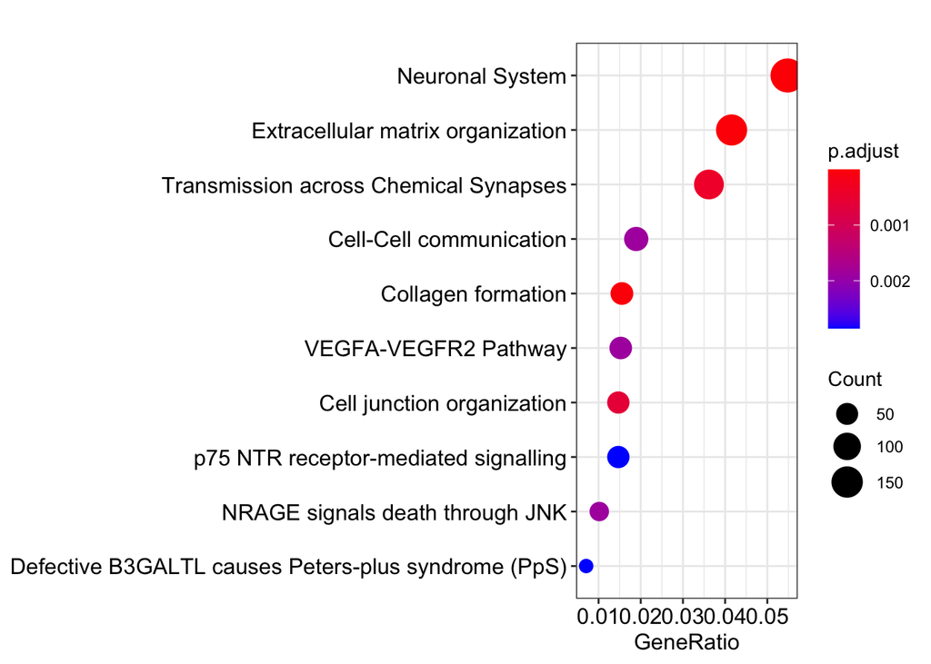

```r
xup <- enrichPathway(gene=deup,pvalueCutoff=0.05, readable=TRUE)
dotplot(xup, showCategory=10)
```